# Compare to Grant 2021

John Favate

2021-07-29 11:36:50

```r
# Prevent printing of warnings and such in the HTML
knitr::opts_chunk$set(warning = FALSE, message = FALSE, fig.align = "center")
```

Load packages

```r
library(tidyverse)
```

This document creates a data frame that allows us to compare our data to that of another paper, Grant 2021 (https://journals.asm.org/doi/10.1128/JB.00469-20). I’ve cloned the github repo for that paper below. **Pay attention** this is supposed to place this repo at the top of the directory tree, i.e. it should be in the same place as directories `alignment` and `code`. If if it doesn’t do that, the rest of the document won’t work. This chunk is set to not run because otherwise it keeps trying to clone into something that already exists. You’ll need to set `eval = TRUE`.

```bash
cd ../..
git clone https://github.com/NkrumahG/LTEE-cell-size-shape.git
```

```r
# original line
# CoultClones <-  list.files(pattern = "*.CSV")

# new line
CoultClones <- list.files("../../LTEE-cell-size-shape/2h.24h-cell-size-csv", pattern = "*.CSV", full.names = TRUE)

CoultCol.namesClones <- c( "x", "seconds", "fL", "um", "population", "generation", "block", "time")

#Here I import the data placing lower and upper bouds on the data at the onset
Coulter.dataClones <- as.data.frame(setNames(do.call(rbind,Map('cbind', lapply(CoultClones, read.csv, skip = 274), V4= CoultClones, V5=CoultClones, V6=CoultClones, V7=CoultClones)), CoultCol.namesClones))  %>%
  subset(fL > 0.200 & fL < 6.00)

#Extrating generation informaiton from the file name
Coulter.dataClones$generation <- as.factor(gsub("_.*","",Coulter.dataClones$generation))

#Extracting population information from the file name and change data order
Coulter.dataClones$population <- as.factor(gsub(".*K_|_2020.*","",Coulter.dataClones$population))
Coulter.dataClones$population <- factor(Coulter.dataClones$population, levels = c("606", "M1", "M2", "M3", "M4", "M5", "M6", "607","P1","P2","P3","P4","P5","P6"))

#Change how populations are named
Coulter.dataClones$population <- gsub("M", "Ara-",Coulter.dataClones$population)
Coulter.dataClones$population <- gsub("P", "Ara+",Coulter.dataClones$population)
Coulter.dataClones$population <- gsub("606", "REL606",Coulter.dataClones$population)
Coulter.dataClones$population <- gsub("607", "REL607",Coulter.dataClones$population)

#Assigning a block number based upon date completed
Coulter.dataClones$block <- as.factor(gsub("^.*2020-01-24.*$","1",Coulter.dataClones$block)) #2h block 1
Coulter.dataClones$block <- as.factor(gsub("^.*2020-01-25.*$","1",Coulter.dataClones$block)) #24h block 1
Coulter.dataClones$block <- as.factor(gsub("^.*2020-02-05.*$","2",Coulter.dataClones$block)) #2h block 2
Coulter.dataClones$block <- as.factor(gsub("^.*2020-02-06.*$","2",Coulter.dataClones$block)) #24h block 2
Coulter.dataClones$block <- as.factor(gsub("^.*2020-02-14.*$","3",Coulter.dataClones$block)) #2h block 3
Coulter.dataClones$block <- as.factor(gsub("^.*2020-02-15.*$","3",Coulter.dataClones$block)) #24h block 3

#Assigning a time based upon date completed
Coulter.dataClones$time <- as.factor(gsub("^.*2020-01-24.*$","Mid-exponential",Coulter.dataClones$time)) #2h block 1
Coulter.dataClones$time <- as.factor(gsub("^.*2020-01-25.*$","Stationary phase",Coulter.dataClones$time)) #24h block 1
Coulter.dataClones$time <- as.factor(gsub("^.*2020-02-05.*$","Mid-exponential",Coulter.dataClones$time)) #2h block 2
Coulter.dataClones$time <- as.factor(gsub("^.*2020-02-06.*$","Stationary phase",Coulter.dataClones$time)) #24h block 2
Coulter.dataClones$time <- as.factor(gsub("^.*2020-02-14.*$","Mid-exponential",Coulter.dataClones$time)) #2h block 3
Coulter.dataClones$time <- as.factor(gsub("^.*2020-02-15.*$","Stationary phase",Coulter.dataClones$time)) #24h block 3

# a line I've added to save the unfiltered data
unfiltered.data <- Coulter.dataClones

#What are the fifth and 95th percentiles of the data between the initial bounds of input data?

#5th?
Coulter.dataClones <- Coulter.dataClones %>%  group_by(population, generation, block, time) %>%
  mutate(fifth = quantile(fL, probs = (.05)))

min(Coulter.dataClones$fifth) #.207
```

```
## [1] 0.207
```

```r
#95th?
Coulter.dataClones <- Coulter.dataClones %>%  group_by(population, generation, block, time) %>%
  mutate(ninety_fifth = quantile(fL, probs = (.95)))

max(Coulter.dataClones$ninety_fifth) #5.6594
```

```
## [1] 5.6594
```

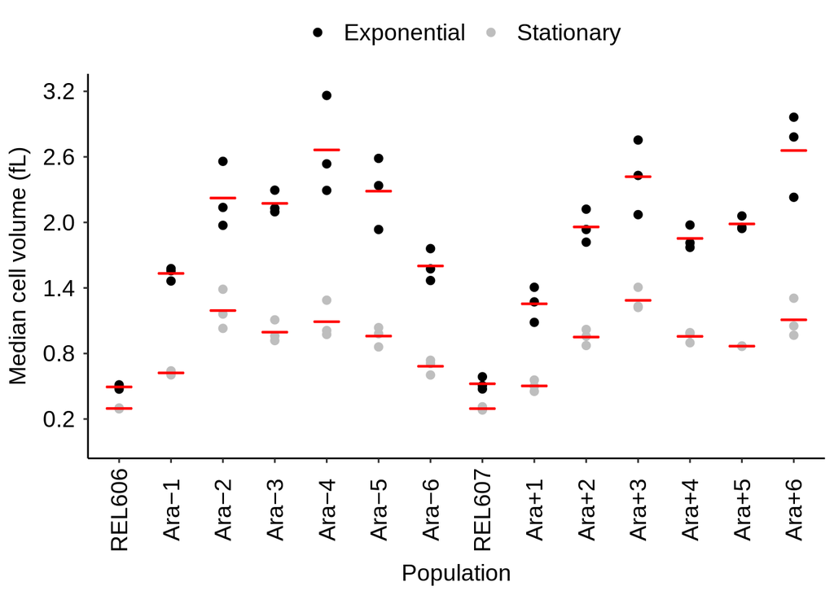

```r
#Now filter dataset keeping only the middle 90% of cell size data  (0.21 <= fL <= 5.66)
Coulter.dataClones <- as.data.frame(Coulter.dataClones %>%  group_by(population, generation, block, time) %>%
  subset(fL > 0.207 & fL < 5.6594))

#Code for calculating standard deviation of a population
#https://www.dummies.com/education/math/statistics/standard-deviation-r/

sd.p=function(x){sd(x)*sqrt((length(x)-1)/length(x))}

d1 <- as.data.frame(Coulter.dataClones %>% group_by(population,block,time) %>%
  summarise(n=n(), median.fL = median(fL), mean.fL = mean(fL), sd.p.fL = sd.p(fL), sd.fL = sd(fL)))

#Order the populations
d1$population <- factor(d1$population, levels = c("REL606", "Ara-1", "Ara-2", "Ara-3", "Ara-4", "Ara-5", "Ara-6", "REL607","Ara+1","Ara+2","Ara+3","Ara+4","Ara+5","Ara+6"))

#True minus between population levels
levels(d1$population) <- c("REL606", "Ara−1", "Ara−2", "Ara−3", "Ara−4", "Ara−5", "Ara−6", "REL607","Ara+1","Ara+2","Ara+3","Ara+4","Ara+5","Ara+6")
d1$time <- factor(d1$time,levels = c("Mid-exponential", "Stationary phase"))
levels(d1$time) <- c("Exponential", "Stationary")

#Plot median estimate of cell size for each replicate and the confidence intervals

d1 %>% ggplot(aes(x = population, y = median.fL, colour = time, group=time)) +
  geom_point(size = 2) +
  stat_summary(fun = mean, fun.min = mean, fun.max = mean, geom = "crossbar", position="identity", color = "red", width = .5, size=.3) +
  labs(x= "Population", y= "Median cell volume (fL)") +
  scale_y_continuous(limits=c(0,3.2), breaks = seq(.2,3.2,.6)) +
  scale_color_manual(values = c("Exponential" = "Black", "Stationary" = "Grey"), name = "") +
  theme_classic()+
  theme(legend.position = "top") +
  theme(axis.text.x = element_text(colour = "black", size = 14, margin = (margin(t = 3, b=5)), angle = (90), vjust = .5)) +
  theme(axis.title.x = element_text( size = 14)) +
  theme(axis.text.y = element_text(colour = "black",  size = 14, margin = (margin(l = 5, r=5)))) +
  theme(axis.title.y = element_text( size = 14)) +
  theme(legend.text = element_text( size = 14)) +
  theme(legend.title = element_text(size = 14)) +
  theme(panel.border = element_blank(), panel.background = element_blank(), axis.line = element_line(colour = "black"))
```

They take the mean of the medians, their filtering has almost no effect on this number.

```r
mean.of.meds <- d1 %>%
  filter(time == "Exponential") %>%
  mutate(population = as.character(population)) %>%
  group_by(population) %>%
  summarise(mean_of_medians = mean(median.fL)) %>%
  ungroup() %>%
  rename("line" = "population")

mean.of.meds
```

| line | mean_of_medians |
| --- | --- |
| Ara+1 | 1.2545000 |
| Ara+2 | 1.9583333 |
| Ara+3 | 2.4183333 |
| Ara+4 | 1.8533333 |
| Ara+5 | 1.9856667 |
| Ara+6 | 2.6583333 |
| Ara−1 | 1.5325000 |
| Ara−2 | 2.2230000 |
| Ara−3 | 2.1736667 |
| Ara−4 | 2.6636667 |

[output cut: 4 more lines]

Somehow, `Coulter.dataClones` and `mean.of.meds` can’t join on the line column. I’ve narrowed this down to the fact that the dash in `mean.of.meds` is longer than the one in `Coulter.dataClones`. This “−” vs this “-”, the second one is the one that comes out of my keyboard whereas the first is copied from the table above. I assume this is due to differences in OS or something but I don’t know. Either way, it has to get corrected.

```r
mean.of.meds <- mean.of.meds %>%
  mutate(line = str_replace(line, "−", "-"))
```

This yields a data frame with all of their data (the filtered data, at least) plus the mean of medians which is what they graph and what we compare to.

```r
df.to.save <- Coulter.dataClones %>%
  filter(time == "Mid-exponential") %>%
  select(population, fL) %>%
  rename("line" = "population") %>%
  left_join(mean.of.meds, by = "line")

head(df.to.save)
```

|  | line | fL | mean_of_medians |
| --- | --- | --- | --- |
| 1 | REL606 | 0.407 | 0.4935 |
| 2 | REL606 | 0.480 | 0.4935 |
| 3 | REL606 | 0.596 | 0.4935 |
| 4 | REL606 | 0.561 | 0.4935 |
| 5 | REL606 | 0.333 | 0.4935 |
| 6 | REL606 | 1.070 | 0.4935 |

Save it

```r
write_csv(df.to.save, "../../data_frames/grant_2021_median_volumes.csv")
```

The filtering they do doesnt make so much of a difference, their data is naturally in that range.

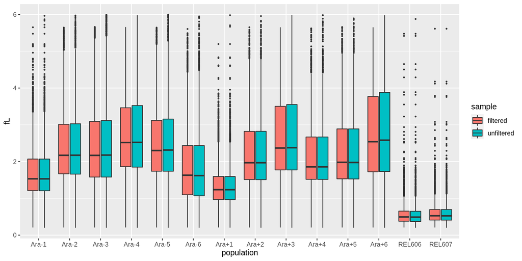

```r
filt <- Coulter.dataClones %>%
  filter(time == "Mid-exponential") %>%
  select(population, fL)

unfilt <- unfiltered.data %>%
  ungroup() %>%
  filter(time == "Mid-exponential") %>%
  select(population, fL)


bind_rows("filtered" = filt,
          "unfiltered" = unfilt,
          .id = "sample") %>%
  ggplot(., aes(population, fL, fill = sample))+
  geom_boxplot(outlier.size = .5)
```